# MATH9102-Phase2-Task4

# STEP 4: Decide on which components to retain

Once the full PCA is run, you need to decide how many components to keep for interpretation. There are two main things to look at:

The scree plot – This helps you visually identify where the “elbow” or point of inflexion is. After this point, the components explain very little additional variance.

Eigenvalues – A common guideline is to keep components with eigenvalues greater than 1 (Kaiser’s criterion) or greater than 0.7 (Joliffe’s criterion).

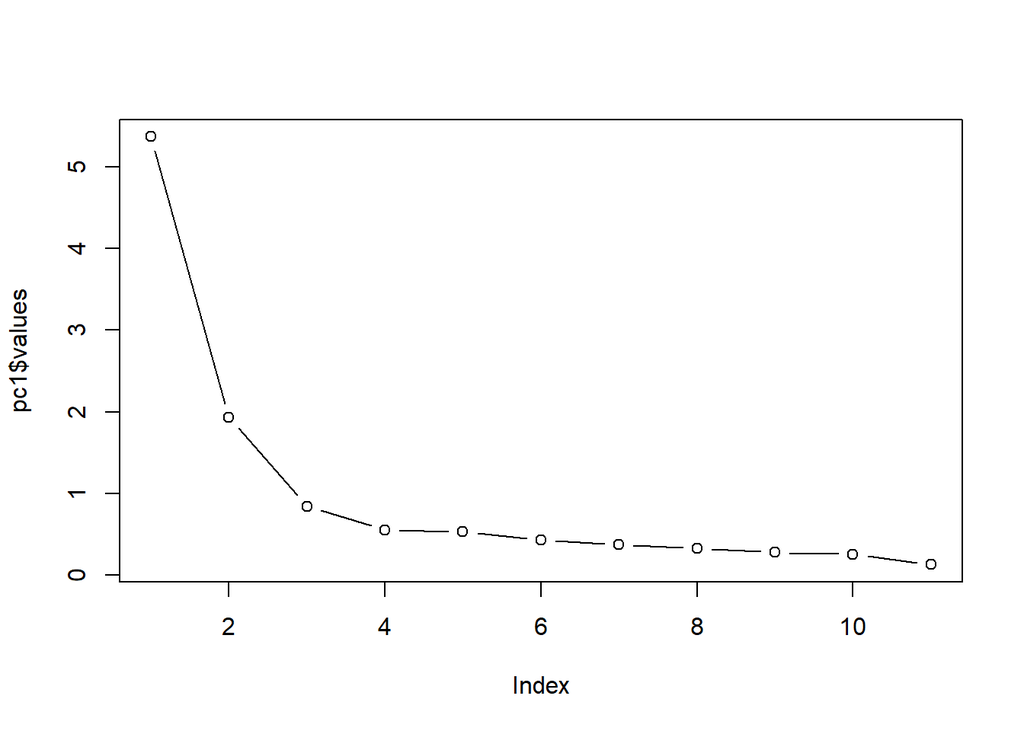

```r
#Create the scree plot
plot(pc1$values, type = "b")
```

```r
#Print the variance explained by each component
pc1$Vaccounted
```

```
                            PC1       PC2        PC3        PC4        PC5
SS loadings           5.3691920 1.9295711 0.83965924 0.55318862 0.52808318
Proportion Var        0.4881084 0.1754156 0.07633266 0.05028987 0.04800756
Cumulative Var        0.4881084 0.6635239 0.73985658 0.79014645 0.83815402
Proportion Explained  0.4881084 0.1754156 0.07633266 0.05028987 0.04800756
Cumulative Proportion 0.4881084 0.6635239 0.73985658 0.79014645 0.83815402
                             PC6        PC7        PC8        PC9       PC10
SS loadings           0.43081272 0.36922369 0.32344323 0.27600845 0.25329275
Proportion Var        0.03916479 0.03356579 0.02940393 0.02509168 0.02302661
Cumulative Var        0.87731881 0.91088460 0.94028853 0.96538021 0.98840682
Proportion Explained  0.03916479 0.03356579 0.02940393 0.02509168 0.02302661
Cumulative Proportion 0.87731881 0.91088460 0.94028853 0.96538021 0.98840682
                            PC11
SS loadings           0.12752498
Proportion Var        0.01159318
Cumulative Var        1.00000000
Proportion Explained  0.01159318
Cumulative Proportion 1.00000000
```

```r
#Print the Eigenvalues
pc1$values
```

```
 [1] 5.3691920 1.9295711 0.8396592 0.5531886 0.5280832 0.4308127 0.3692237
 [8] 0.3234432 0.2760084 0.2532927 0.1275250
```

```r
#Another way to look at the eigenvalues plus variance explained (need to use princomp function of PCA to get right class for use with factoextra functions)
pcf=princomp(uxData)
factoextra::get_eigenvalue(pcf)
```

```
       eigenvalue variance.percent cumulative.variance.percent
Dim.1  22.2044804        47.804527                    47.80453
Dim.2   8.6287260        18.576979                    66.38151
Dim.3   3.6889808         7.942090                    74.32360
Dim.4   2.4230127         5.216559                    79.54015
Dim.5   2.2842408         4.917794                    84.45795
Dim.6   1.8791881         4.045746                    88.50369
Dim.7   1.4424291         3.105438                    91.60913
Dim.8   1.2679015         2.729694                    94.33883
Dim.9   1.1053225         2.379674                    96.71850
Dim.10  0.9844934         2.119538                    98.83804
Dim.11  0.5397140         1.161963                   100.00000
```

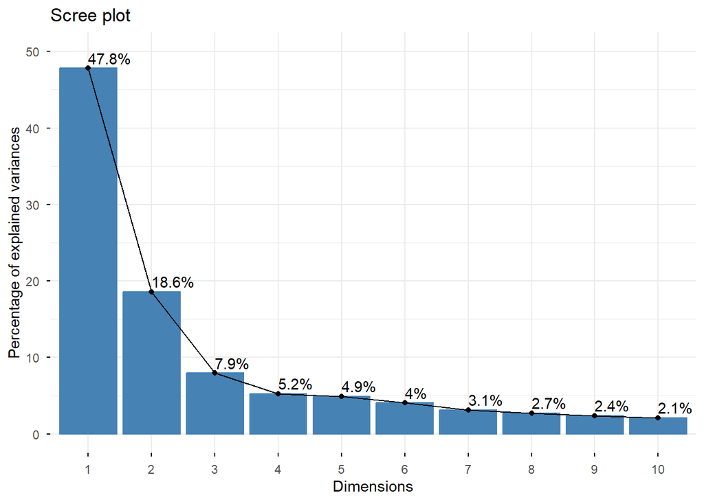

```r
factoextra::fviz_eig(pcf, addlabels = TRUE, ylim = c(0, 50))#Visualize the Eigenvalues
```

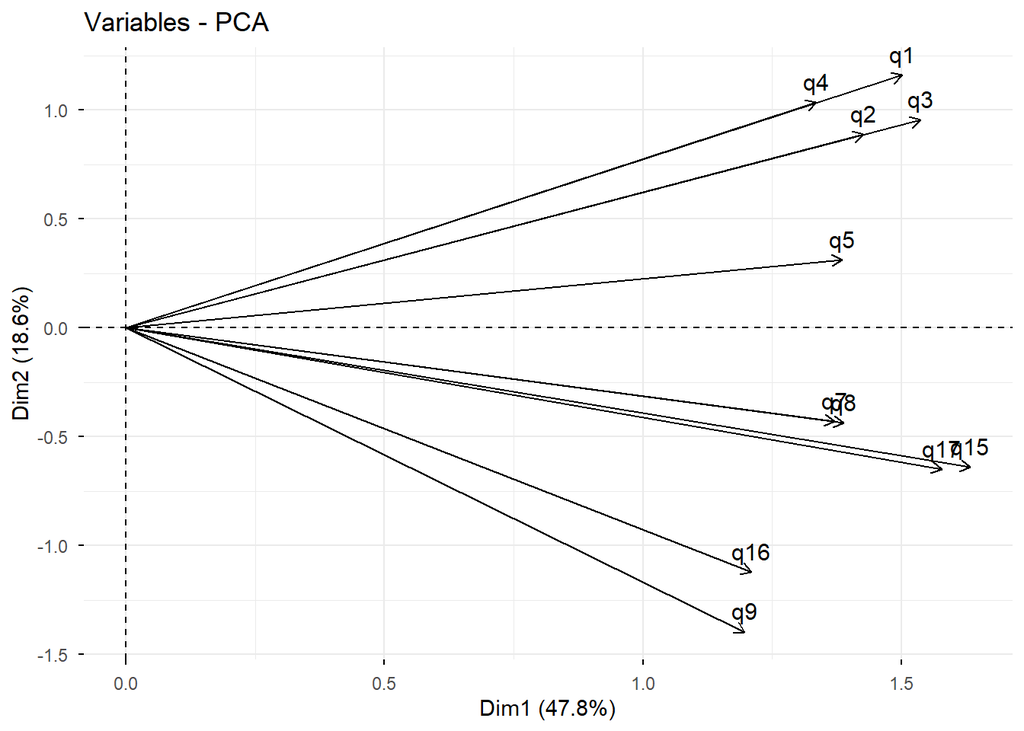

```r
factoextra::fviz_pca_var(pcf, col.var = "black")
```

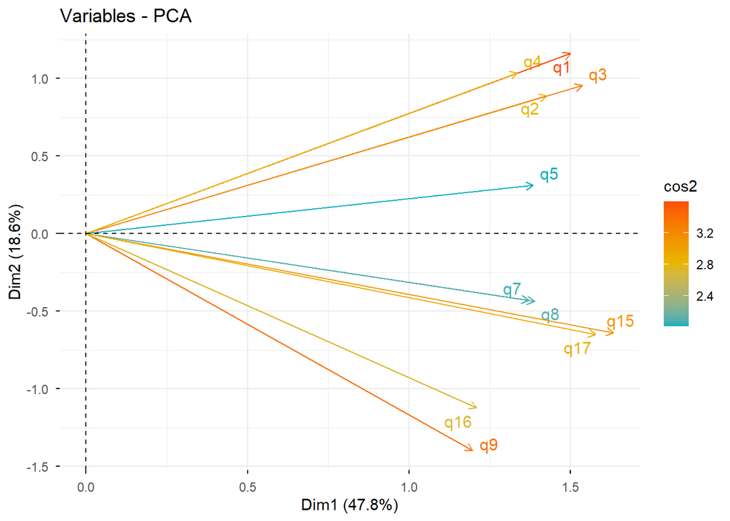

```r
factoextra::fviz_pca_var(pcf, col.var = "cos2",
             gradient.cols = c("#00AFBB", "#E7B800", "#FC4E07"),
             repel = TRUE # Avoid text overlapping
             )
```

```r
#Print the loadings above the level of 0.3
psych::print.psych(pc1, cut = 0.3, sort = TRUE)
```

```
Principal Components Analysis
Call: principal(r = uxData, nfactors = length(uxData), rotate = "none")
Standardized loadings (pattern matrix) based upon correlation matrix
    item  PC1   PC2   PC3   PC4   PC5   PC6   PC7   PC8   PC9 PC10 PC11 h2
q5     5 0.81                               -0.38                        1
q17   11 0.77  0.35                                     -0.31            1
q15    9 0.76  0.32                                0.38                  1
q2     2 0.74 -0.47                                                      1
q8     8 0.74             -0.48                                          1
q7     7 0.71       -0.48                                                1
q1     1 0.69 -0.51                                                      1
q3     3 0.69 -0.41                    0.42                              1
q4     4 0.67 -0.52  0.31                                                1
q16   10 0.55  0.52  0.39        0.43                                    1
q9     6 0.51  0.58  0.39       -0.38                                    1
         u2 com
q5  1.9e-15 2.2
q17 1.4e-15 2.7
q15 1.6e-15 2.7
q2  1.8e-15 2.7
q8  1.3e-15 2.8
q7  1.7e-15 3.1
q1  0.0e+00 3.3
q3  0.0e+00 3.4
q4  3.2e-15 3.4
q16 2.2e-16 4.4
q9  5.6e-16 4.4

                       PC1  PC2  PC3  PC4  PC5  PC6  PC7  PC8  PC9 PC10 PC11
SS loadings           5.37 1.93 0.84 0.55 0.53 0.43 0.37 0.32 0.28 0.25 0.13
Proportion Var        0.49 0.18 0.08 0.05 0.05 0.04 0.03 0.03 0.03 0.02 0.01
Cumulative Var        0.49 0.66 0.74 0.79 0.84 0.88 0.91 0.94 0.97 0.99 1.00
Proportion Explained  0.49 0.18 0.08 0.05 0.05 0.04 0.03 0.03 0.03 0.02 0.01
Cumulative Proportion 0.49 0.66 0.74 0.79 0.84 0.88 0.91 0.94 0.97 0.99 1.00

Mean item complexity =  3.2
Test of the hypothesis that 11 components are sufficient.

The root mean square of the residuals (RMSR) is  0
 with the empirical chi square  0  with prob <  NA

Fit based upon off diagonal values = 1
```

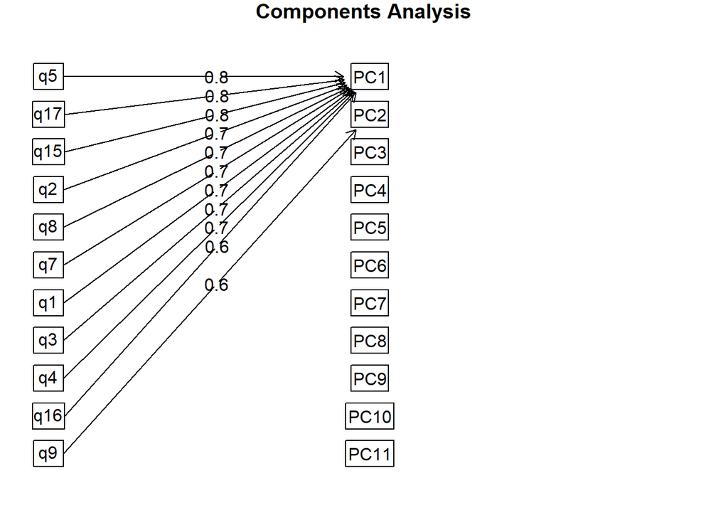

```r
#Create a diagram showing the components and how the manifest variables load
fa.diagram(pc1)
```

```r
#Show the loadings of variables on to components
fa.sort(pc1$loading)
```

```
Loadings:
    PC1    PC2    PC3    PC4    PC5    PC6    PC7    PC8    PC9    PC10
q5   0.807 -0.181         0.171 -0.169 -0.138 -0.381 -0.250        -0.156
q17  0.766  0.354 -0.194 -0.212  0.242        -0.104        -0.311 -0.138
q15  0.758  0.320 -0.227        -0.186 -0.226         0.384         0.117
q2   0.744 -0.470  0.121  0.188        -0.104  0.251        -0.263
q8   0.737  0.263        -0.476 -0.172 -0.137  0.241 -0.142  0.158
q7   0.707  0.268 -0.482  0.101  0.148  0.216        -0.221         0.252
q1   0.693 -0.507 -0.247  0.201         0.147  0.211         0.151 -0.189
q3   0.687 -0.411  0.190 -0.284         0.419 -0.183  0.157
q4   0.668 -0.523  0.310         0.157 -0.229                       0.270
q16  0.552  0.518  0.391  0.185  0.432                       0.186 -0.106
q9   0.508  0.583  0.395  0.189 -0.375  0.178               -0.119
    PC11
q5
q17  0.123
q15
q2  -0.179
q8
q7
q1   0.162
q3
q4   0.150
q16
q9   0.110

                 PC1   PC2   PC3   PC4   PC5   PC6   PC7   PC8   PC9  PC10
SS loadings    5.369 1.930 0.840 0.553 0.528 0.431 0.369 0.323 0.276 0.253
Proportion Var 0.488 0.175 0.076 0.050 0.048 0.039 0.034 0.029 0.025 0.023
Cumulative Var 0.488 0.664 0.740 0.790 0.838 0.877 0.911 0.940 0.965 0.988
                PC11
SS loadings    0.128
Proportion Var 0.012
Cumulative Var 1.000
```

Communalities - tell us how much of each variable’s variance is captured by the components we keep. A communality close to 1 means the retained components represent that variable very well. A communality below about 0.4 may indicate that the variable is not well represented.

```r
#Output the communalities of variables across components (will be one for PCA since all the variance is used)
pc1$communality
```

```
 q1  q2  q3  q4  q5  q9  q7  q8 q15 q16 q17
  1   1   1   1   1   1   1   1   1   1   1
```

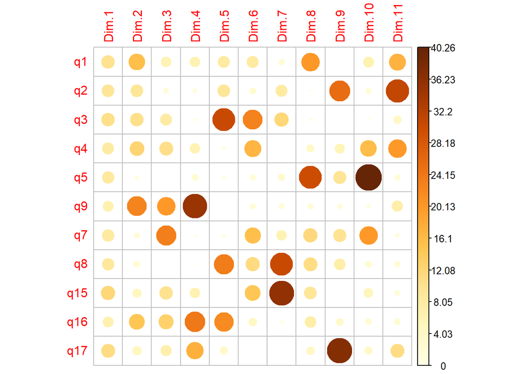

```r
#Visualize contribution of variables to each component
var <- factoextra::get_pca_var(pcf)
corrplot::corrplot(var$contrib, is.corr=FALSE)
```

***If you want to visualize the contributions of the variables to each component use this code**

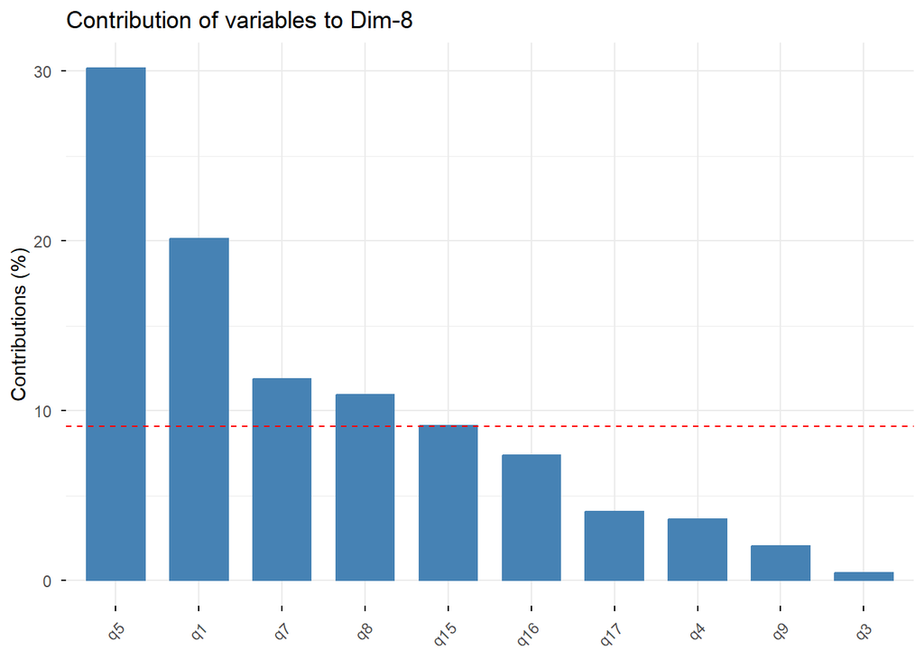

```r
# Contributions of variables to PC?
factoextra::fviz_contrib(pcf, choice = "var", axes = 8, top = 10)# Replace the value for axes with the number of the component e.g. 1 for PC1, 2 for PC2, 8 for PC8
```